# Lotto EDA project

Loading Packages into R

```r
library(tidyverse)
library(here)
library(lubridate)
player <- read.csv("C://Users/samir/Documents/player.csv")
transaction_type <- read.csv("C://Users/samir/Documents/transaction_type.csv")
transaction <- read.csv("C://Users/samir/Documents/transaction.csv")
transaction <- transaction %>% mutate(BOOKINGDATE = lubridate::as_date(BOOKINGDATE))
```

For The first few chunks I’m just going to generate some charts to get a feel of the Player Demographics

The density plot below represents the distribution of the birth years. From the density plot we can get a feel of the distribution of age demographics

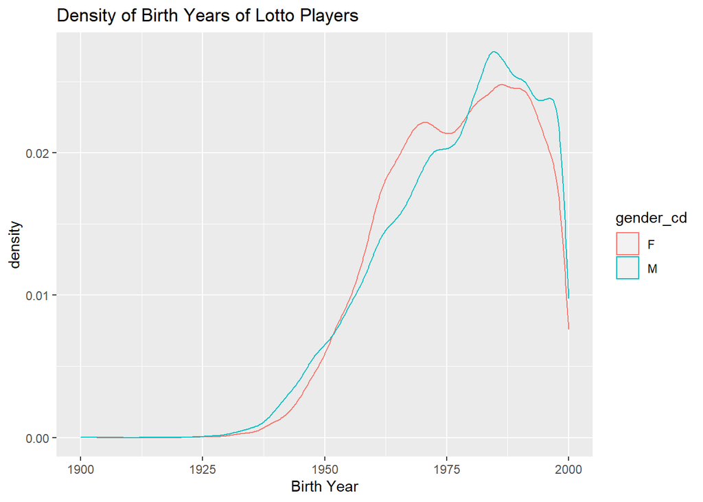

```r
player %>%
  ggplot(aes(lubridate::year(birth_date), color = gender_cd)) +
  geom_density() +
  xlab("Birth Year") +
  ggtitle("Density of Birth Years of Lotto Players")
```

In this chart I aim to identify the preferred platforms each generational cohort uses.

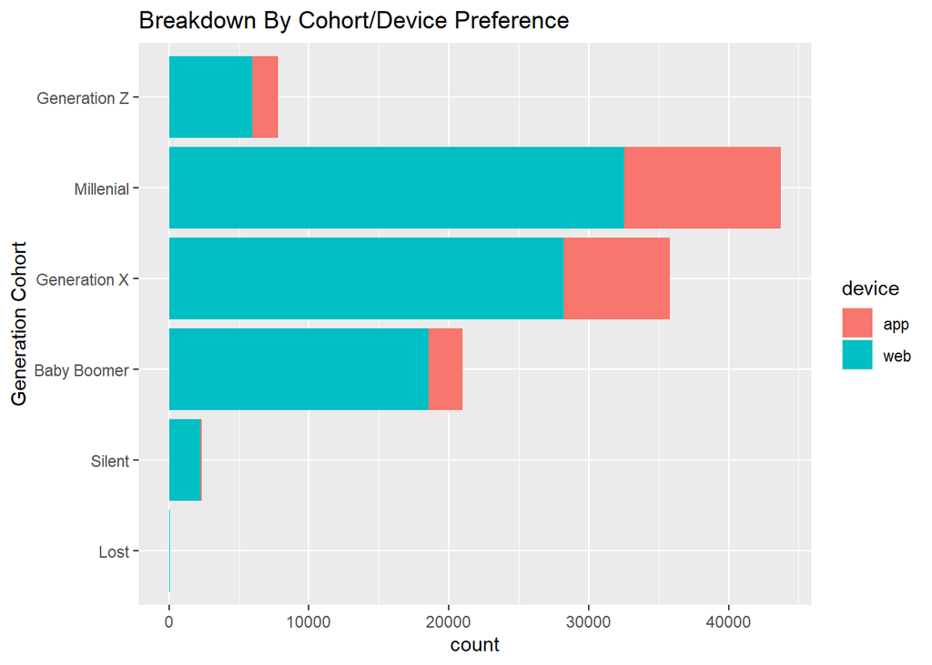

```r
levels <- c("Lost", "Silent", "Baby Boomer", "Generation X", "Millenial", "Generation Z")

player_by_cohort <- player %>%
  mutate(cohort = case_when(
    year(birth_date) < 1928 ~ "Lost",
    year(birth_date) %in% 1929:1945 ~ "Silent",
    year(birth_date) %in% 1946:1964 ~ "Baby Boomer",
    year(birth_date) %in% 1965:1980 ~ "Generation X",
    year(birth_date) %in% 1981:1996 ~ "Millenial",
    year(birth_date) >= 1997 ~ "Generation Z"
  )) %>%
  filter(!is.na(cohort))

player_by_cohort %>%
  ggplot(aes(factor(cohort, levels = levels), fill = device)) +
    geom_bar(stat = "count") +
    coord_flip() +
    xlab("Generation Cohort") +
    ggtitle("Breakdown By Cohort/Device Preference")
```

The two largest generational cohorts are Millennial and Generation X. Furthermore, although using the web platforms are dominant throughout the cohorts, the Millennial and Gen X cohorts do have frequent users of the applications.

```r
bonus <- transaction %>%
  left_join(transaction_type, by = c("CLASSNAME" = "src_classname_txt")) %>%
  group_by(ACCOUNT_ID) %>%
  filter(any(trx_category_cd == "bonus"))
```

The chart below aims to identify seasonal trends in when individuals want to purchase tickets

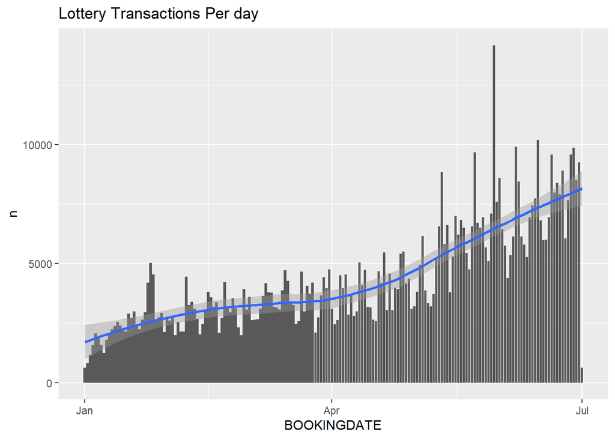

```r
trans_per_date <- transaction %>%
  left_join(transaction_type, by = c("CLASSNAME" = "src_classname_txt")) %>%
  group_by(BOOKINGDATE) %>%
  filter(!is.na(TICKETTYPE), TICKETTYPE != "", trx_category_cd == "stake") %>%
  count(TICKETTYPE) %>%
  summarise(n = sum(n))

trans_per_date %>% ggplot(aes(x = BOOKINGDATE, y = n)) + geom_col() + geom_smooth() +
  ggtitle("Lottery Transactions Per day")
```

From the chart, we can see that as the season transitions into the summertime, an increased number of tickets get sold. Perhaps an ad campaign can be launched in late April or Early May with the goal of increasing lotto ticket purchases.

The following is the same chart from above but broken down by gender.

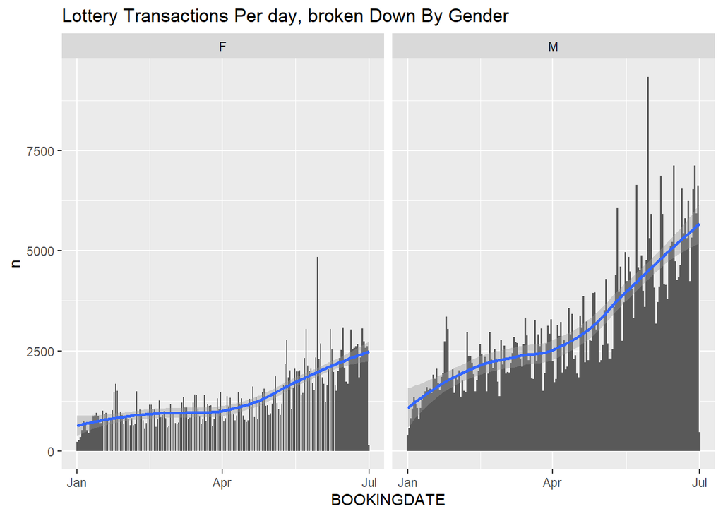

```r
transaction %>%
  left_join(transaction_type, by = c("CLASSNAME" = "src_classname_txt")) %>%
  left_join(player, by = c("ACCOUNT_ID" = "src_account_id" )) %>%
  group_by(BOOKINGDATE, gender_cd) %>%
  filter(!is.na(TICKETTYPE), TICKETTYPE != "", trx_category_cd == "stake") %>%
  count(TICKETTYPE) %>%
  summarise(n = sum(n)) %>%
  ggplot(aes(x = BOOKINGDATE, y = n)) + geom_col() + geom_smooth() +
  ggtitle("Lottery Transactions Per day, broken Down By Gender") +
  facet_wrap(~gender_cd)
```

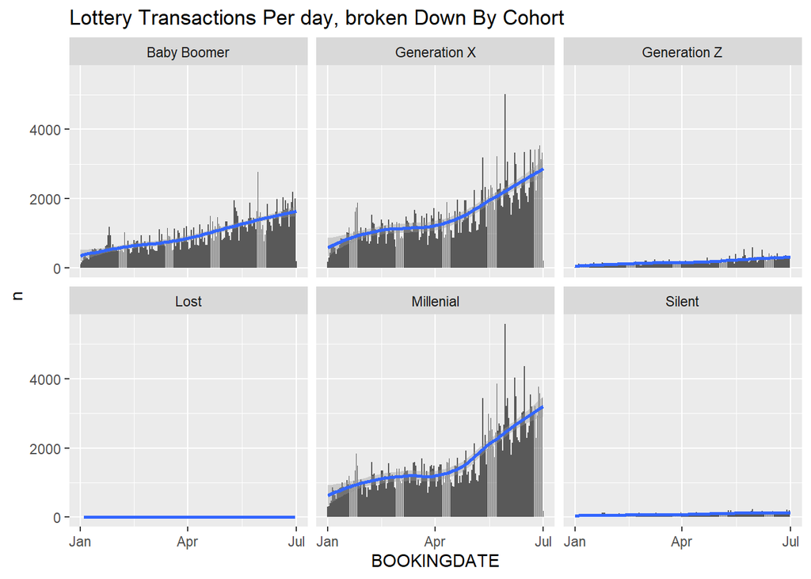

```r
transaction %>%
  left_join(transaction_type, by = c("CLASSNAME" = "src_classname_txt")) %>%
  left_join(player_by_cohort, by = c("ACCOUNT_ID" = "src_account_id" )) %>%
  group_by(BOOKINGDATE, cohort) %>%
  filter(!is.na(TICKETTYPE), TICKETTYPE != "", trx_category_cd == "stake", !is.na(cohort)) %>%
  count(TICKETTYPE) %>%
  summarise(n = sum(n)) %>%
  ggplot(aes(x = BOOKINGDATE, y = n)) + geom_col() + geom_smooth() +
  ggtitle("Lottery Transactions Per day, broken Down By Cohort") +
  facet_wrap(~cohort)
```

When breaking the stakes by cohort, there are some noticeable patterns. The baby boomer generation has more of a steady increase through the time period. The Generation Z cohort is more steady when it comes to creating stakes. Lastly, Generation X and the Millennial cohorts witness similar Springtime spikes in purchasing of stakes.

```r
ticket_winnings <- transaction %>%
  left_join(player, by = c("ACCOUNT_ID" = "src_account_id")) %>%
  left_join(transaction_type, by = c("CLASSNAME" = "src_classname_txt"))%>%
  filter(trx_category_cd == "win") %>%
  mutate(winnings = POSTBALANCE - PREBALANCE)

temp_plot <- ticket_winnings %>%
  filter(currency_cd == c("AUD  ", "EUR  ")) %>%
  select(currency_cd, TICKETTYPE, winnings) %>%
  ggplot(aes(x = TICKETTYPE, Y = winnings)) +
  geom_boxplot() +
  facet_wrap(~currency_cd)
```

[figure not shown]

```r
temp_plot
```